Pular para o conteúdo principal

# Tempo até a decisão liminar em Habeas Corpus no TJAL

HCs (classe 307) ajuizados na 2ª instância em fevereiro de 2026

Data de Publicação

22/11/2026

# 1 Resumo

Dos **150** Habeas Corpus ajuizados na 2ª instância do TJAL em fevereiro de 2026, **107** (71,3%) tiveram uma decisão liminar registrada. Entre eles, a primeira decisão saiu em **3,8 dias** (mediana), com metade dos casos entre 2,1 e 6,0 dias. Nenhum caso passou de 14,8 dias. A grande maioria das liminares foi **denegada** (93 de 107).

# 2 Metodologia

## 2.1 Fonte e recorte

- **Fonte:** API Pública do DataJud (CNJ), índice `api_publica_tjal`, acessada pelo pacote R `jjesusfilho/datajud`.
- **Recorte:** classe processual TPU **307 (Habeas Corpus)**, grau **G2**, `dataAjuizamento` entre 01/02/2026 e 28/02/2026.
- **Coleta** (`R/01_coleta.R`): `search_slice()`, que baixa cada fatia em uma única requisição e confere se a resposta veio completa. A paginação comum (`from`/`size`) repete e pula documentos nessa API. A coleta trouxe 150 processos, sem números duplicados.
- **Data de corte** (último movimento registrado na base): 02/10/2026.

## 2.2 Definição do tempo

O tempo é medido do **ajuizamento** (`dataAjuizamento`) até o **primeiro movimento de decisão liminar**:

Tabela 1: Códigos TPU tratados como decisão liminar

| Código | Hierarquia TPU | Resultado | Regra |
| --- | --- | --- | --- |
| 339 | Decisão › Concessão › Liminar | Concedida | Sempre |
| 892 | Decisão › Concessão em parte › Liminar | Concedida em parte | Sempre |
| 792 | Decisão › Não-Concessão › Liminar | Denegada | Sempre |
| 12444 | Decisão › Deferimento | Concedida | Só antes do julgamento |
| 15086 | Decisão › Deferimento em Parte | Concedida em parte | Só antes do julgamento |
| 15223 | Decisão › Prejudicado o Pedido | Prejudicada | Só antes do julgamento |

- **Data de distribuição:** foi descartada como ponto de partida. O movimento 26 (Distribuição) falta em 22 processos, que começam por redistribuição. Quando existe, ele ocorre poucos minutos após o ajuizamento.
- **Códigos genéricos:** em alguns HCs o TJAL lançou a liminar como “deferimento” em vez do código específico. Esses códigos (12444, 15086,
  15223. só contam se registrados antes do primeiro julgamento, para não confundir a liminar com decisões posteriores.
- **Fuso horário:** os movimentos trazem o sufixo `Z`, mas estão no mesmo relógio do `dataAjuizamento`. A distribuição ocorre minutos depois do ajuizamento e nenhum movimento é anterior a ele. Se o `Z` fosse UTC de fato, haveria tempos negativos de cerca de 3 horas.

## 2.3 Validações

| Verificação | Resultado |
| --- | --- |
| Processos sem duplicata de numeroProcesso | Sim |
| Tempos negativos até a liminar | 0 |
| Movimentos anteriores ao ajuizamento | 0 |
| Processos com mais de uma decisão liminar | 0 (apenas a primeira é usada) |
| Movimentos sem código TPU | 934 de 6166 (15,1%) |
| Código 1059 (recurso) lançado em HC — excluído | 23 movimentos |

Os movimentos sem código não têm nome nem complemento e não podem ser classificados. Se algum deles for uma decisão liminar, ela não aparece aqui, e o processo é contado como sem liminar.

# 3 Dados censurados: HCs sem decisão liminar

Nem todo HC termina com uma decisão liminar registrada. Os 43 processos sem esse movimento se dividem em dois grupos com tratamento diferente:

Tabela 2: Desfecho de cada HC na data de corte

| Desfecho | N | Tratamento | % |
| --- | --- | --- | --- |
| censurado | 1 | Censura à direita (na data de corte) | 0,7% |
| julgamento sem liminar | 42 | Risco competitivo | 28,0% |
| liminar | 107 | Evento de interesse | 71,3% |

- **Julgamento sem liminar (42 HCs):** o processo foi julgado ou extinto sem nenhuma decisão liminar registrada. A explicação mais provável é que não houvesse pedido liminar, ou que o pedido tenha sido apreciado junto com o mérito. Depois do julgamento a liminar não pode mais acontecer, então esse desfecho é um **risco competitivo**, e não uma censura comum. Tratá-lo como censura (Kaplan-Meier) superestimaria a chance de haver liminar.
- **Censurado (1 HC):** sem liminar e sem julgamento até a data de corte. O tempo observado é só um limite inferior, e o processo entra como **censura à direita**.

Por isso o relatório usa dois recortes:

1. **Estatística descritiva condicional:** só os 107 HCs com liminar. Responde: *quando há decisão liminar, quanto tempo ela leva?*
2. **Incidência acumulada (estimador de Aalen-Johansen):** todos os 150 HCs. Responde: *qual a probabilidade de um HC ter decisão liminar até o dia t?* O estimador leva em conta a censura e o risco competitivo.

# 4 Estatísticas descritivas

Tabela 3: Tempo do ajuizamento à primeira decisão liminar (dias), HCs com liminar

| Grupo | N | Mínimo | Q1 | Mediana | Média | Q3 | IQR | Máximo | Desvio-padrão |
| --- | --- | --- | --- | --- | --- | --- | --- | --- | --- |
| Concedida | 11 | 0,92 | 2,41 | 3,05 | 3,93 | 4,67 | 2,25 | 9,66 | 2,85 |
| Concedida em parte | 3 | 2,09 | 4,07 | 6,05 | 4,75 | 6,07 | 2,00 | 6,10 | 2,30 |
| Denegada | 93 | 0,09 | 2,07 | 3,96 | 4,35 | 5,95 | 3,88 | 14,78 | 2,97 |
| Todos | 107 | 0,09 | 2,09 | 3,79 | 4,31 | 5,97 | 3,87 | 14,78 | 2,93 |

- **Média e mediana:** a média (4,31 dias) fica acima da mediana (3,79 dias), um sinal de assimetria à direita: alguns casos demoram bem mais que o típico.
- **IQR:** 3,87 dias, ou seja, metade dos HCs com liminar teve a decisão dentro de uma janela de pouco menos de 4 dias.
- **Dias corridos:** contando dias de calendário, a mediana é de 4 dias, e 86,0% das liminares saíram em até 7 dias corridos.
- **Concedidas:** 14 liminares concedidas, integral ou parcialmente. É um número pequeno, então a comparação entre os grupos é só descritiva.

# 5 Visualizações

## 5.1 Distribuição do tempo até a liminar

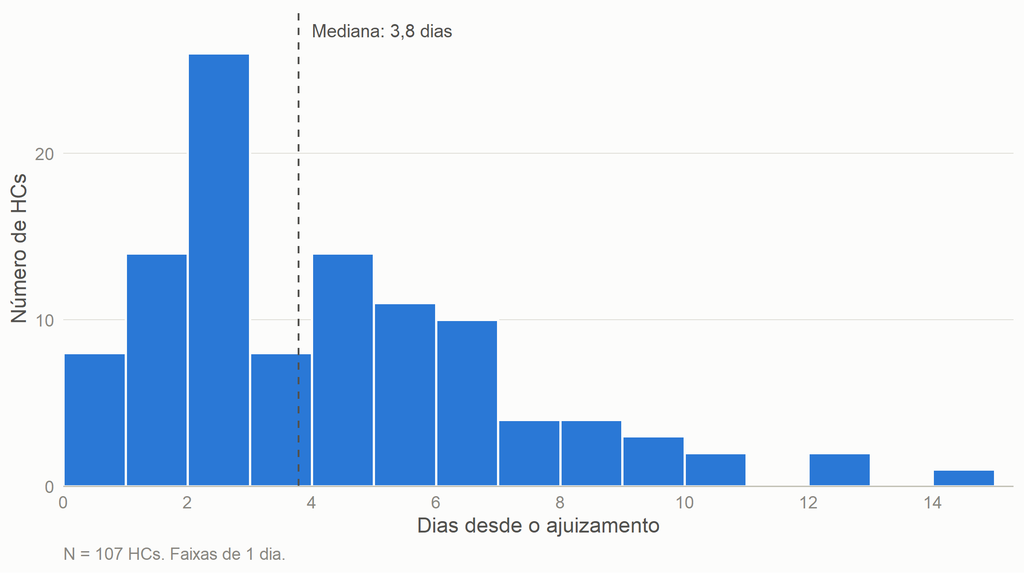

Figura 1: Distribuição do tempo até a primeira decisão liminar (HCs com liminar). A linha tracejada marca a mediana.

## 5.2 Tempo por resultado da liminar

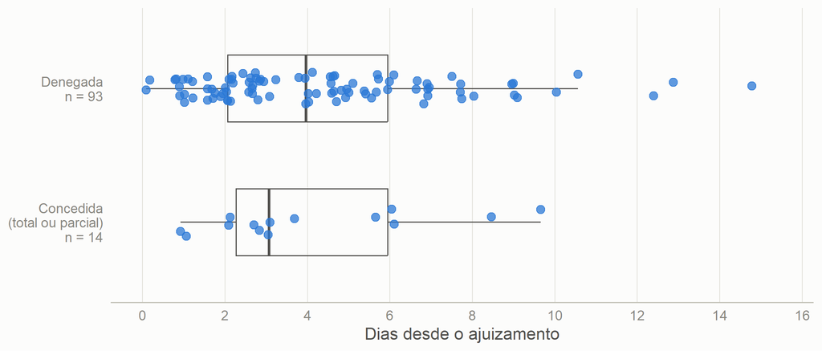

Figura 2: Tempo até a liminar por resultado. Cada ponto é um HC; a caixa marca o intervalo interquartil e a linha central, a mediana.

## 5.3 Incidência acumulada com risco competitivo

Pelo estimador de Aalen-Johansen, a probabilidade de um HC ter decisão liminar é de **60,7% em até 7 dias** e de **70,7% em até 14 dias**. A curva chega a 71,3%, porque os demais HCs foram julgados sem liminar. Metade de todos os HCs já tinha decisão liminar no dia **5,6** após o ajuizamento.

Para comparar: um Kaplan-Meier que tratasse o julgamento como censura estimaria 64,2% em 7 dias. É uma superestimação, porque supõe que os HCs julgados ainda poderiam receber liminar.

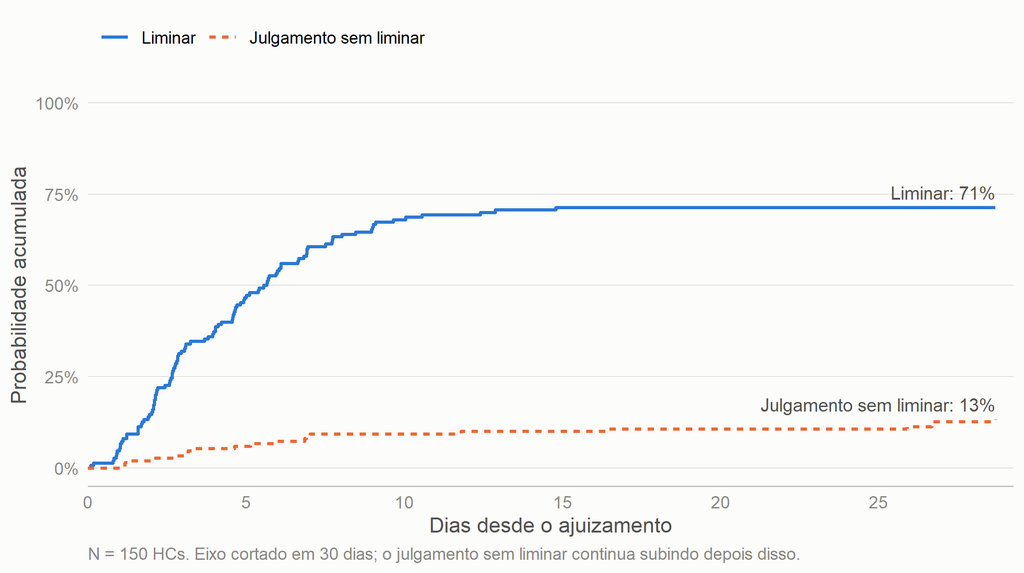

Figura 3: Incidência acumulada (Aalen-Johansen) dos dois desfechos competitivos, todos os HCs.

# 6 Limitações

- **Ausência de pedido:** o DataJud não informa se houve pedido liminar. Os HCs julgados sem liminar podem não ter tido pedido, e por isso a incidência acumulada mede a chance de haver *decisão liminar registrada*, não a taxa de apreciação dos pedidos.
- **Movimentos sem código:** 15,1% dos movimentos não têm código TPU. Liminares registradas assim ficam invisíveis.
- **Codificação local:** o TJAL usa códigos genéricos em parte dos casos (deferimento em vez de liminar concedida) e lança o código 1059, de recurso, em HCs. A regra adotada para os genéricos depende da data do julgamento.
- **Recorte de um mês:** com 150 processos, e só 14 liminares concedidas, as comparações entre subgrupos são descritivas.

# 7 Reprodutibilidade

| Etapa | Arquivo | Saída |
| --- | --- | --- |
| Setup e smoke test | R/00_setup.R | — |
| Coleta | R/01_coleta.R | data/hc_tjal_fev2026.rds |
| Tratamento | R/02_analise.R | data/hc_tjal_tratado.rds |
| Relatório | relatorio.qmd | relatorio.html |

Ambiente: R version 4.6.2 (2026-10-29 ucrt); pacotes `datajud` 0.2.0.9000, `tidyverse` 2.0.0, `survival` 3.8.12.